# Data Preparation

Fazle Rabbi

October 21, 2015

We now begin with the task of preparing our data for building models using R.

The required packages for this tutorial:

```r
library(rattle)                       # the weather dataset and normVarNames()
library(randomForest)                 # Input missing values using na. roughfix()
```

```r
library(tidyr)                        # Tidy the dataset
library(ggplot2)                      # Visualize data
library(dplyr)                        # data preparation and pipes %>%
library(lubridate)                    # handle dates
library(FSelector)                    # feature selection
```

We begin by noting the path to the CSV file we wish to load

```r
dspath <- "http://rattle.togaware.com/weather.csv"
weather <- read.csv(dspath)
dsname <- "weather"
ds <- get(dsname)                # generic name
```

Once it is loaded we might like to get a basic idea of what it looks like

```r
dim(ds)
```

```
## [1] 366  24
```

```r
names(ds)
```

```
##  [1] "Date"          "Location"      "MinTemp"       "MaxTemp"
##  [5] "Rainfall"      "Evaporation"   "Sunshine"      "WindGustDir"
##  [9] "WindGustSpeed" "WindDir9am"    "WindDir3pm"    "WindSpeed9am"
## [13] "WindSpeed3pm"  "Humidity9am"   "Humidity3pm"   "Pressure9am"
## [17] "Pressure3pm"   "Cloud9am"      "Cloud3pm"      "Temp9am"
## [21] "Temp3pm"       "RainToday"     "RISK_MM"       "RainTomorrow"
```

```r
str(ds)
```

```
## 'data.frame':    366 obs. of  24 variables:
##  $ Date         : Factor w/ 366 levels "2007-11-01","2007-11-02",..: 1 2 3 4 5 6 7 8 9 10 ...
##  $ Location     : Factor w/ 1 level "Canberra": 1 1 1 1 1 1 1 1 1 1 ...
##  $ MinTemp      : num  8 14 13.7 13.3 7.6 6.2 6.1 8.3 8.8 8.4 ...
##  $ MaxTemp      : num  24.3 26.9 23.4 15.5 16.1 16.9 18.2 17 19.5 22.8 ...
##  $ Rainfall     : num  0 3.6 3.6 39.8 2.8 0 0.2 0 0 16.2 ...
##  $ Evaporation  : num  3.4 4.4 5.8 7.2 5.6 5.8 4.2 5.6 4 5.4 ...
##  $ Sunshine     : num  6.3 9.7 3.3 9.1 10.6 8.2 8.4 4.6 4.1 7.7 ...
##  $ WindGustDir  : Factor w/ 16 levels "E","ENE","ESE",..: 8 2 8 8 11 10 10 1 9 1 ...
##  $ WindGustSpeed: int  30 39 85 54 50 44 43 41 48 31 ...
##  $ WindDir9am   : Factor w/ 16 levels "E","ENE","ESE",..: 13 1 4 15 11 10 10 10 1 9 ...
##  $ WindDir3pm   : Factor w/ 16 levels "E","ENE","ESE",..: 8 14 6 14 3 1 3 1 2 3 ...
##  $ WindSpeed9am : int  6 4 6 30 20 20 19 11 19 7 ...
##  $ WindSpeed3pm : int  20 17 6 24 28 24 26 24 17 6 ...
##  $ Humidity9am  : int  68 80 82 62 68 70 63 65 70 82 ...
##  $ Humidity3pm  : int  29 36 69 56 49 57 47 57 48 32 ...
##  $ Pressure9am  : num  1020 1012 1010 1006 1018 ...
##  $ Pressure3pm  : num  1015 1008 1007 1007 1018 ...
##  $ Cloud9am     : int  7 5 8 2 7 7 4 6 7 7 ...
##  $ Cloud3pm     : int  7 3 7 7 7 5 6 7 7 1 ...
##  $ Temp9am      : num  14.4 17.5 15.4 13.5 11.1 10.9 12.4 12.1 14.1 13.3 ...
##  $ Temp3pm      : num  23.6 25.7 20.2 14.1 15.4 14.8 17.3 15.5 18.9 21.7 ...
##  $ RainToday    : Factor w/ 2 levels "No","Yes": 1 2 2 2 2 1 1 1 1 2 ...
##  $ RISK_MM      : num  3.6 3.6 39.8 2.8 0 0.2 0 0 16.2 0 ...
##  $ RainTomorrow : Factor w/ 2 levels "No","Yes": 2 2 2 2 1 1 1 1 2 1 ...
```

## Step 1: Convenience of Table Data Frame

Another tip in dealing with larger datasets is to make use of tbl df() to add a couple of extra classes to the data frame. The simple aim here is to avoid the often made “mistake” of printing the whole data frame accidentally.

```r
class(ds)
```

```
## [1] "data.frame"
```

```r
ds <- tbl_df(ds)
class(ds)
```

```
## [1] "tbl_df"     "tbl"        "data.frame"
```

The default print() method reports the dimensions and then the first few rows and columns.

```r
ds
```

```
## Source: local data frame [366 x 24]
##
##          Date Location MinTemp MaxTemp Rainfall Evaporation Sunshine
##        (fctr)   (fctr)   (dbl)   (dbl)    (dbl)       (dbl)    (dbl)
## 1  2007-11-01 Canberra     8.0    24.3      0.0         3.4      6.3
## 2  2007-11-02 Canberra    14.0    26.9      3.6         4.4      9.7
## 3  2007-11-03 Canberra    13.7    23.4      3.6         5.8      3.3
## 4  2007-11-04 Canberra    13.3    15.5     39.8         7.2      9.1
## 5  2007-11-05 Canberra     7.6    16.1      2.8         5.6     10.6
## 6  2007-11-06 Canberra     6.2    16.9      0.0         5.8      8.2
## 7  2007-11-07 Canberra     6.1    18.2      0.2         4.2      8.4
## 8  2007-11-08 Canberra     8.3    17.0      0.0         5.6      4.6
## 9  2007-11-09 Canberra     8.8    19.5      0.0         4.0      4.1
## 10 2007-11-10 Canberra     8.4    22.8     16.2         5.4      7.7
## ..        ...      ...     ...     ...      ...         ...      ...
## Variables not shown: WindGustDir (fctr), WindGustSpeed (int), WindDir9am
##   (fctr), WindDir3pm (fctr), WindSpeed9am (int), WindSpeed3pm (int),
##   Humidity9am (int), Humidity3pm (int), Pressure9am (dbl), Pressure3pm
##   (dbl), Cloud9am (int), Cloud3pm (int), Temp9am (dbl), Temp3pm (dbl),
##   RainToday (fctr), RISK_MM (dbl), RainTomorrow (fctr)
```

## Step 2: Review - Observations

```r
head(ds)
```

```
## Source: local data frame [6 x 24]
##
##         Date Location MinTemp MaxTemp Rainfall Evaporation Sunshine
##       (fctr)   (fctr)   (dbl)   (dbl)    (dbl)       (dbl)    (dbl)
## 1 2007-11-01 Canberra     8.0    24.3      0.0         3.4      6.3
## 2 2007-11-02 Canberra    14.0    26.9      3.6         4.4      9.7
## 3 2007-11-03 Canberra    13.7    23.4      3.6         5.8      3.3
## 4 2007-11-04 Canberra    13.3    15.5     39.8         7.2      9.1
## 5 2007-11-05 Canberra     7.6    16.1      2.8         5.6     10.6
## 6 2007-11-06 Canberra     6.2    16.9      0.0         5.8      8.2
## Variables not shown: WindGustDir (fctr), WindGustSpeed (int), WindDir9am
##   (fctr), WindDir3pm (fctr), WindSpeed9am (int), WindSpeed3pm (int),
##   Humidity9am (int), Humidity3pm (int), Pressure9am (dbl), Pressure3pm
##   (dbl), Cloud9am (int), Cloud3pm (int), Temp9am (dbl), Temp3pm (dbl),
##   RainToday (fctr), RISK_MM (dbl), RainTomorrow (fctr)
```

```r
tail(ds)
```

```
## Source: local data frame [6 x 24]
##
##         Date Location MinTemp MaxTemp Rainfall Evaporation Sunshine
##       (fctr)   (fctr)   (dbl)   (dbl)    (dbl)       (dbl)    (dbl)
## 1 2008-10-26 Canberra     7.9    26.1        0         6.8      3.5
## 2 2008-10-27 Canberra     9.0    30.7        0         7.6     12.1
## 3 2008-10-28 Canberra     7.1    28.4        0        11.6     12.7
## 4 2008-10-29 Canberra    12.5    19.9        0         8.4      5.3
## 5 2008-10-30 Canberra    12.5    26.9        0         5.0      7.1
## 6 2008-10-31 Canberra    12.3    30.2        0         6.0     12.6
## Variables not shown: WindGustDir (fctr), WindGustSpeed (int), WindDir9am
##   (fctr), WindDir3pm (fctr), WindSpeed9am (int), WindSpeed3pm (int),
##   Humidity9am (int), Humidity3pm (int), Pressure9am (dbl), Pressure3pm
##   (dbl), Cloud9am (int), Cloud3pm (int), Temp9am (dbl), Temp3pm (dbl),
##   RainToday (fctr), RISK_MM (dbl), RainTomorrow (fctr)
```

```r
ds[sample(nrow(ds),6),]    # sample creates random indices here (6 indices)
```

```
## Source: local data frame [6 x 24]
##
##         Date Location MinTemp MaxTemp Rainfall Evaporation Sunshine
##       (fctr)   (fctr)   (dbl)   (dbl)    (dbl)       (dbl)    (dbl)
## 1 2008-07-22 Canberra    -2.2    11.6      0.0         1.4      9.2
## 2 2007-11-08 Canberra     8.3    17.0      0.0         5.6      4.6
## 3 2008-04-03 Canberra     7.0    14.3      2.6         9.6      9.7
## 4 2008-04-19 Canberra     8.4    16.1      0.0         3.0      4.9
## 5 2008-10-16 Canberra     4.4    21.0      0.0         4.2     12.2
## 6 2007-12-12 Canberra    11.7    21.5      0.0         4.2      7.3
## Variables not shown: WindGustDir (fctr), WindGustSpeed (int), WindDir9am
##   (fctr), WindDir3pm (fctr), WindSpeed9am (int), WindSpeed3pm (int),
##   Humidity9am (int), Humidity3pm (int), Pressure9am (dbl), Pressure3pm
##   (dbl), Cloud9am (int), Cloud3pm (int), Temp9am (dbl), Temp3pm (dbl),
##   RainToday (fctr), RISK_MM (dbl), RainTomorrow (fctr)
```

## Step 2: Review - Structure

```r
str(ds)
```

```
## Classes 'tbl_df', 'tbl' and 'data.frame':    366 obs. of  24 variables:
##  $ Date         : Factor w/ 366 levels "2007-11-01","2007-11-02",..: 1 2 3 4 5 6 7 8 9 10 ...
##  $ Location     : Factor w/ 1 level "Canberra": 1 1 1 1 1 1 1 1 1 1 ...
##  $ MinTemp      : num  8 14 13.7 13.3 7.6 6.2 6.1 8.3 8.8 8.4 ...
##  $ MaxTemp      : num  24.3 26.9 23.4 15.5 16.1 16.9 18.2 17 19.5 22.8 ...
##  $ Rainfall     : num  0 3.6 3.6 39.8 2.8 0 0.2 0 0 16.2 ...
##  $ Evaporation  : num  3.4 4.4 5.8 7.2 5.6 5.8 4.2 5.6 4 5.4 ...
##  $ Sunshine     : num  6.3 9.7 3.3 9.1 10.6 8.2 8.4 4.6 4.1 7.7 ...
##  $ WindGustDir  : Factor w/ 16 levels "E","ENE","ESE",..: 8 2 8 8 11 10 10 1 9 1 ...
##  $ WindGustSpeed: int  30 39 85 54 50 44 43 41 48 31 ...
##  $ WindDir9am   : Factor w/ 16 levels "E","ENE","ESE",..: 13 1 4 15 11 10 10 10 1 9 ...
##  $ WindDir3pm   : Factor w/ 16 levels "E","ENE","ESE",..: 8 14 6 14 3 1 3 1 2 3 ...
##  $ WindSpeed9am : int  6 4 6 30 20 20 19 11 19 7 ...
##  $ WindSpeed3pm : int  20 17 6 24 28 24 26 24 17 6 ...
##  $ Humidity9am  : int  68 80 82 62 68 70 63 65 70 82 ...
##  $ Humidity3pm  : int  29 36 69 56 49 57 47 57 48 32 ...
##  $ Pressure9am  : num  1020 1012 1010 1006 1018 ...
##  $ Pressure3pm  : num  1015 1008 1007 1007 1018 ...
##  $ Cloud9am     : int  7 5 8 2 7 7 4 6 7 7 ...
##  $ Cloud3pm     : int  7 3 7 7 7 5 6 7 7 1 ...
##  $ Temp9am      : num  14.4 17.5 15.4 13.5 11.1 10.9 12.4 12.1 14.1 13.3 ...
##  $ Temp3pm      : num  23.6 25.7 20.2 14.1 15.4 14.8 17.3 15.5 18.9 21.7 ...
##  $ RainToday    : Factor w/ 2 levels "No","Yes": 1 2 2 2 2 1 1 1 1 2 ...
##  $ RISK_MM      : num  3.6 3.6 39.8 2.8 0 0.2 0 0 16.2 0 ...
##  $ RainTomorrow : Factor w/ 2 levels "No","Yes": 2 2 2 2 1 1 1 1 2 1 ...
```

## Step 2: Review - Summay

The first quartile (Q1) is defined as the middle number between the smallest number and the median of the data set.

```r
summary(ds)
```

```
##          Date         Location      MinTemp          MaxTemp
##  2007-11-01:  1   Canberra:366   Min.   :-5.300   Min.   : 7.60
##  2007-11-02:  1                  1st Qu.: 2.300   1st Qu.:15.03
##  2007-11-03:  1                  Median : 7.450   Median :19.65
##  2007-11-04:  1                  Mean   : 7.266   Mean   :20.55
##  2007-11-05:  1                  3rd Qu.:12.500   3rd Qu.:25.50
##  2007-11-06:  1                  Max.   :20.900   Max.   :35.80
##  (Other)   :360
##     Rainfall       Evaporation        Sunshine       WindGustDir
##  Min.   : 0.000   Min.   : 0.200   Min.   : 0.000   NW     : 73
##  1st Qu.: 0.000   1st Qu.: 2.200   1st Qu.: 5.950   NNW    : 44
##  Median : 0.000   Median : 4.200   Median : 8.600   E      : 37
##  Mean   : 1.428   Mean   : 4.522   Mean   : 7.909   WNW    : 35
##  3rd Qu.: 0.200   3rd Qu.: 6.400   3rd Qu.:10.500   ENE    : 30
##  Max.   :39.800   Max.   :13.800   Max.   :13.600   (Other):144
##                                    NA's   :3        NA's   :  3
##  WindGustSpeed     WindDir9am    WindDir3pm   WindSpeed9am
##  Min.   :13.00   SE     : 47   NW     : 61   Min.   : 0.000
##  1st Qu.:31.00   SSE    : 40   WNW    : 61   1st Qu.: 6.000
##  Median :39.00   NNW    : 36   NNW    : 47   Median : 7.000
##  Mean   :39.84   N      : 31   N      : 30   Mean   : 9.652
##  3rd Qu.:46.00   NW     : 30   ESE    : 27   3rd Qu.:13.000
##  Max.   :98.00   (Other):151   (Other):139   Max.   :41.000
##  NA's   :2       NA's   : 31   NA's   :  1   NA's   :7
##   WindSpeed3pm    Humidity9am     Humidity3pm     Pressure9am
##  Min.   : 0.00   Min.   :36.00   Min.   :13.00   Min.   : 996.5
##  1st Qu.:11.00   1st Qu.:64.00   1st Qu.:32.25   1st Qu.:1015.4
##  Median :17.00   Median :72.00   Median :43.00   Median :1020.1
##  Mean   :17.99   Mean   :72.04   Mean   :44.52   Mean   :1019.7
##  3rd Qu.:24.00   3rd Qu.:81.00   3rd Qu.:55.00   3rd Qu.:1024.5
##  Max.   :52.00   Max.   :99.00   Max.   :96.00   Max.   :1035.7
##
##   Pressure3pm        Cloud9am        Cloud3pm        Temp9am
##  Min.   : 996.8   Min.   :0.000   Min.   :0.000   Min.   : 0.100
##  1st Qu.:1012.8   1st Qu.:1.000   1st Qu.:1.000   1st Qu.: 7.625
##  Median :1017.4   Median :3.500   Median :4.000   Median :12.550
##  Mean   :1016.8   Mean   :3.891   Mean   :4.025   Mean   :12.358
##  3rd Qu.:1021.5   3rd Qu.:7.000   3rd Qu.:7.000   3rd Qu.:17.000
##  Max.   :1033.2   Max.   :8.000   Max.   :8.000   Max.   :24.700
##
##     Temp3pm      RainToday    RISK_MM       RainTomorrow
##  Min.   : 5.10   No :300   Min.   : 0.000   No :300
##  1st Qu.:14.15   Yes: 66   1st Qu.: 0.000   Yes: 66
##  Median :18.55             Median : 0.000
##  Mean   :19.23             Mean   : 1.428
##  3rd Qu.:24.00             3rd Qu.: 0.200
##  Max.   :34.50             Max.   :39.800
##
```

## Step 2: Review - Meta Data Cleansing

**Normalize variable names:** R is case sensitive. normVarNames() from rattle, converts variables into a standard form.

```r
names(ds) <- normVarNames(names(ds))
names(ds)
```

```
##  [1] "date"            "location"        "min_temp"
##  [4] "max_temp"        "rainfall"        "evaporation"
##  [7] "sunshine"        "wind_gust_dir"   "wind_gust_speed"
## [10] "wind_dir_9am"    "wind_dir_3pm"    "wind_speed_9am"
## [13] "wind_speed_3pm"  "humidity_9am"    "humidity_3pm"
## [16] "pressure_9am"    "pressure_3pm"    "cloud_9am"
## [19] "cloud_3pm"       "temp_9am"        "temp_3pm"
## [22] "rain_today"      "risk_mm"         "rain_tomorrow"
```

## Step 2: Review - Data Formats

We might first check the data type of each variable.

```r
sapply(ds, class)
```

```
##            date        location        min_temp        max_temp
##        "factor"        "factor"       "numeric"       "numeric"
##        rainfall     evaporation        sunshine   wind_gust_dir
##       "numeric"       "numeric"       "numeric"        "factor"
## wind_gust_speed    wind_dir_9am    wind_dir_3pm  wind_speed_9am
##       "integer"        "factor"        "factor"       "integer"
##  wind_speed_3pm    humidity_9am    humidity_3pm    pressure_9am
##       "integer"       "integer"       "integer"       "numeric"
##    pressure_3pm       cloud_9am       cloud_3pm        temp_9am
##       "numeric"       "integer"       "integer"       "numeric"
##        temp_3pm      rain_today         risk_mm   rain_tomorrow
##       "numeric"        "factor"       "numeric"        "factor"
```

**Convert factor to date variable** We note that the date variable is a factor rather than a date. Thus we may like to convert it into a date using lubridate.

```r
library(lubridate)
head(ds$date)
```

```
## [1] 2007-11-01 2007-11-02 2007-11-03 2007-11-04 2007-11-05 2007-11-06
## 366 Levels: 2007-11-01 2007-11-02 2007-11-03 2007-11-04 ... 2008-10-31
```

```r
ds$date <- ymd(as.character(ds$date))
head(ds$date)
```

```
## [1] "2007-11-01 UTC" "2007-11-02 UTC" "2007-11-03 UTC" "2007-11-04 UTC"
## [5] "2007-11-05 UTC" "2007-11-06 UTC"
```

```r
sapply(ds, class)
```

```
## $date
## [1] "POSIXct" "POSIXt"
##
## $location
## [1] "factor"
##
## $min_temp
## [1] "numeric"
##
## $max_temp
## [1] "numeric"
##
## $rainfall
## [1] "numeric"
##
## $evaporation
## [1] "numeric"
##
## $sunshine
## [1] "numeric"
##
## $wind_gust_dir
## [1] "factor"
##
## $wind_gust_speed
## [1] "integer"
##
## $wind_dir_9am
## [1] "factor"
##
## $wind_dir_3pm
## [1] "factor"
##
## $wind_speed_9am
## [1] "integer"
##
## $wind_speed_3pm
## [1] "integer"
##
## $humidity_9am
```

[output cut: 16 more lines]

```
##
## $temp_9am
## [1] "numeric"
##
## $temp_3pm
## [1] "numeric"
##
## $rain_today
## [1] "factor"
##
## $risk_mm
## [1] "numeric"
##
## $rain_tomorrow
## [1] "factor"
```

## Step 2: Review - Variable Roles

Identify the role played by each variable. 1. date is not relevant. We can convert it to season. 2. location can be removed. It is constant. 3. risk is an output variable. It is a measure of the amount of risk or the importance of an observation with respect. Should not be used as input variable.

```r
(vars <- names(ds))
```

```
##  [1] "date"            "location"        "min_temp"
##  [4] "max_temp"        "rainfall"        "evaporation"
##  [7] "sunshine"        "wind_gust_dir"   "wind_gust_speed"
## [10] "wind_dir_9am"    "wind_dir_3pm"    "wind_speed_9am"
## [13] "wind_speed_3pm"  "humidity_9am"    "humidity_3pm"
## [16] "pressure_9am"    "pressure_3pm"    "cloud_9am"
## [19] "cloud_3pm"       "temp_9am"        "temp_3pm"
## [22] "rain_today"      "risk_mm"         "rain_tomorrow"
```

```r
target <- "rain_tomorrow"
risk <- "risk_mm"
id <- c("date", "location")
```

## Step 3: Clean - Ignore IDs, Outputs, Missing

**IDs and Outputs:** We start with the identifiers and the risk variable (which is an output variable). These should play no role in the modelling.

```r
ignore <- union(id, if (exists("risk")) risk)
```

We might also identify any variable that has a unique value for every observation. These are sometimes identifiers as well and if so are candidates for ignoring.

```r
(ids <- which(sapply(ds, function(x) length(unique(x))) == nrow(ds)))
```

```
## date
##    1
```

```r
ignore <- union(ignore, names(ids))
```

**All Missing:** We then remove any variables where all of the values are missing.

```r
mvc <- sapply(ds[vars], function(x) sum(is.na(x)))
mvc <- names(which(mvc == nrow(ds)))
ignore <- union(ignore, mvc)
```

**Missing Many:** Maybe we want to ignore variables with more than 70% missing.

```r
mvn <- sapply(ds[vars], function(x) sum(is.na(x)))
mvn <- names(which(mvn >= 0.7*nrow(ds)))
ignore <- union(ignore, mvn)
```

## Step 3: Clean - Ignore MultiLevel, Constants

**Too Many Levels:** We may want to ignore variables with too many levels. Another approach is to group the levels into a smaller number of levels.

```r
factors <- which(sapply(ds[vars], is.factor))
lvls <- sapply(factors, function(x) length(levels(ds[[x]])))
(many <- names(which(lvls > 20)))
```

```
## character(0)
```

```r
ignore <- union(ignore, many)
```

**Contants:** Ignore variables with constant values

```r
(constants <- names(which(sapply(ds[vars], function(x) all(x == x[1L])))))
```

```
## [1] "location"
```

```r
ignore <- union(ignore, constants)
```

## Step 3: Clean - Identify Correlated Variables

Here we can identify pairs where we want to keep one but not the other, because they are highly correlated. We will select them manually since it is a judgement call. Normally we might limit the removals to those correlations that are 0.95 or more.

```r
library(dplyr)

mc <- cor(ds[which(sapply(ds, is.numeric))], use="complete.obs")
mc[upper.tri(mc, diag=TRUE)] <- NA
mc <-
    mc                              %>%
    abs()                           %>%
    data.frame()                    %>%
    mutate(var1=row.names(mc))      %>%
    gather(var2, cor, -var1)        %>%
    na.omit()

mc <- mc[order(-abs(mc$cor)),]
mc
```

```
##                var1            var2         cor
## 33         temp_3pm        max_temp 0.989104911
## 182    pressure_3pm    pressure_9am 0.966604486
## 15         temp_9am        min_temp 0.915643957
## 32         temp_9am        max_temp 0.869727997
## 254        temp_3pm        temp_9am 0.843836925
## 78     humidity_3pm        sunshine 0.760942386
## 2          max_temp        min_temp 0.749570594
## 16         temp_3pm        min_temp 0.720308771
## 66         temp_9am     evaporation 0.703483280
## 93   wind_speed_3pm wind_gust_speed 0.694428277
## 81        cloud_9am        sunshine 0.688459327
## 21      evaporation        max_temp 0.686875021
## 67         temp_3pm     evaporation 0.668503863
## 82        cloud_3pm        sunshine 0.662973208
```

[output cut: 122 more lines]

```r
ignore <- union(ignore, c("temp_3pm", "pressure_9am", "temp_9am"))
```

## Step 3: Clean - Remove the Variables

Remove the ignorable variables

```r
length(vars)
```

```
## [1] 24
```

```r
vars <- setdiff(vars, ignore)
length(vars)
```

```
## [1] 18
```

## Step 3: Clean - Feature Selection

The FSelector package provides functions to identify the subset of variables that might be more effective for modeling.

```r
library(FSelector)                # information.gain()

form <- formula(paste(target, "~ ."))
cfs(form, ds[vars])
```

```
## [1] "min_temp"        "sunshine"        "wind_gust_speed" "humidity_3pm"
## [5] "pressure_3pm"    "cloud_3pm"
```

```r
information.gain(form, ds[vars])
```

```
##                 attr_importance
## min_temp           3.539250e-02
## max_temp           0.000000e+00
## rainfall           0.000000e+00
## evaporation        0.000000e+00
## sunshine           6.523179e-02
## wind_gust_dir      4.073802e-02
## wind_gust_speed    3.931861e-02
## wind_dir_9am       3.537000e-02
## wind_dir_3pm       1.759904e-02
## wind_speed_9am     9.813415e-05
## wind_speed_3pm     0.000000e+00
## humidity_9am       2.858310e-02
## humidity_3pm       6.189702e-02
## pressure_3pm       6.878745e-02
## cloud_9am          3.314110e-02
## cloud_3pm          6.893149e-02
## rain_today         1.261390e-02
```

## Step 3: Clean - Remove Missing Target

```r
dim(ds)
```

```
## [1] 366  24
```

```r
sum(is.na(ds[target]))
```

```
## [1] 0
```

```r
ds <- ds[!is.na(ds[target]),]
sum(is.na(ds[target]))
```

```
## [1] 0
```

```r
dim(ds)
```

```
## [1] 366  24
```

## Step 3: Clean - Deal with Missing Values

Missing values for the variables are an issue for some but not all model builders. For example, randomForest() has not been coded to handle missing values whilst rpart() has a particularly well developed approach to dealing with missing values.

Here we do this using na.roughfix() from randomForest just for demonstration. Not really doing it.

```r
ods <- ds
dim(ds[vars])
```

```
## [1] 366  18
```

```r
sum(is.na(ds[vars]))
```

```
## [1] 47
```

```r
ds[vars] <- na.roughfix(ds[vars])
sum(is.na(ds[vars]))
```

```
## [1] 0
```

```r
dim(ds[vars])
```

```
## [1] 366  18
```

```r
ds <- ods                     # restore the original
```

## Step 3: Clean - Omitting Observations

We might want to simply remove observations that have missing values. Here na.omit() identifies the rows to omit based on the vars to be included for modeling.

This list of rows to omit is stored as the na.action attribute of the returned object. We then remove these observations from the dataset.

```r
ods <- ds
omit <- NULL

dim(ds[vars])
```

```
## [1] 366  18
```

```r
sum(is.na(ds[vars]))
```

```
## [1] 47
```

```r
mo <- attr(na.omit(ds[vars]), "na.action")
omit <- union(omit, mo)
if (length(omit)) ds <- ds[-omit,]
sum(is.na(ds[vars]))
```

```
## [1] 0
```

```r
dim(ds[vars])
```

```
## [1] 328  18
```

```r
ds <- ods
```

## Step 3: Clean - Normalise Factors

Some variables will have levels with spaces, and mixture of cases, etc. We may like to normalise the levels for each of the categoric variables.

```r
factors <- which(sapply(ds[vars], is.factor))
for(f in factors) {
  levels(ds[[f]]) <- normVarNames(levels(ds[[f]]))
}
```

## Step 3: Clean - Ensure Target is Categoric

For classification models we want to ensure the target is categoric. Often it is 0/1 and hence is loaded as numeric.

```r
ds[target] <- as.factor(ds[[target]])
table(ds[target])
```

```
##
##  No Yes
## 300  66
```

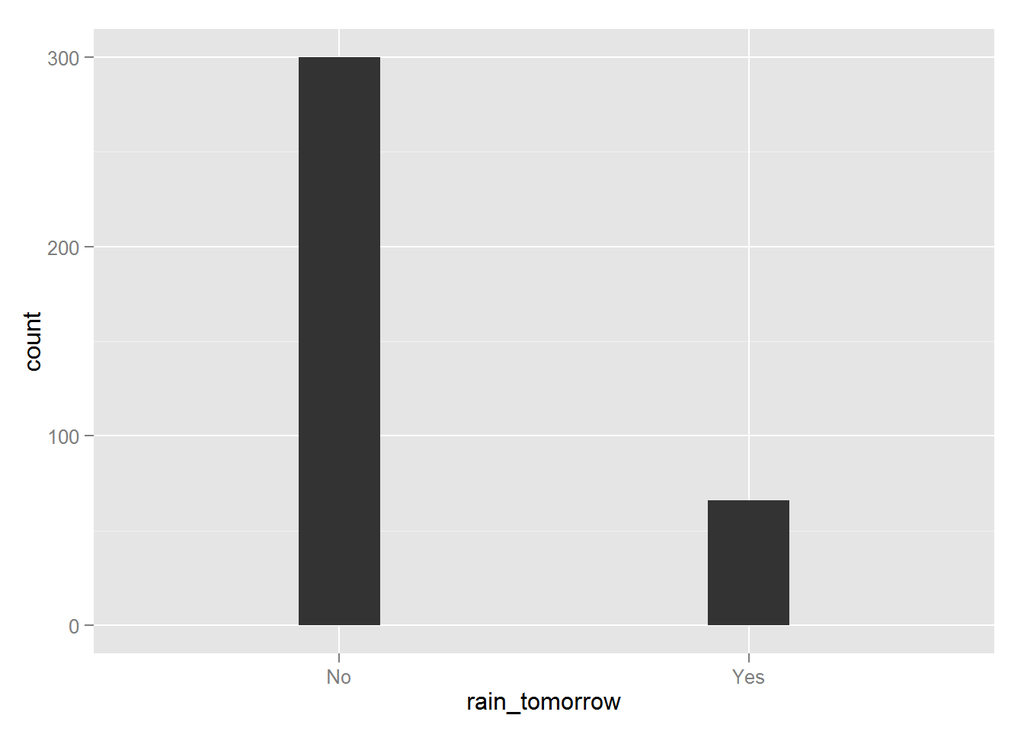

```r
p <- ggplot(ds, aes_string(x=target))
p <- p + geom_bar(width=0.2)
print(p)
```

## Step 4: Prepare Variables

We are now ready to identify the variables that we will use to build the model.

```r
inputc <- setdiff(vars, target)
inputc
```

```
##  [1] "min_temp"        "max_temp"        "rainfall"
##  [4] "evaporation"     "sunshine"        "wind_gust_dir"
##  [7] "wind_gust_speed" "wind_dir_9am"    "wind_dir_3pm"
## [10] "wind_speed_9am"  "wind_speed_3pm"  "humidity_9am"
## [13] "humidity_3pm"    "pressure_3pm"    "cloud_9am"
## [16] "cloud_3pm"       "rain_today"
```

The indices are determined from the names of the variables in the original dataset. Not the use of USE.NAMES= to turn of the inclusion of names of the elements of the resulting vector, only to keep things simpler.

```r
inputi <- sapply(inputc, function(x) which(x == names(ds)), USE.NAMES=FALSE)

inputi
```

```
##  [1]  3  4  5  6  7  8  9 10 11 12 13 14 15 17 18 19 22
```

```r
nobs <- nrow(ds)  # number of observations
nobs
```

```
## [1] 366
```

Reporting the dimensions

```r
dim(ds)
```

```
## [1] 366  24
```

```r
dim(ds[vars])
```

```
## [1] 366  18
```

```r
dim(ds[inputc])
```

```
## [1] 366  17
```

```r
dim(ds[inputi])
```

```
## [1] 366  17
```

## Step 4: Prepare - Numeric and Categoric Variables

Sometimes we need to identify the numeric and categoric variables. Many cluster analysis algorithms only deal with numeric variables, for example.

```r
numi <- intersect(inputi, which(sapply(ds, is.numeric)))
numi
```

```
##  [1]  3  4  5  6  7  9 12 13 14 15 17 18 19
```

```r
numc <- names(ds)[numi]
numc
```

```
##  [1] "min_temp"        "max_temp"        "rainfall"
##  [4] "evaporation"     "sunshine"        "wind_gust_speed"
##  [7] "wind_speed_9am"  "wind_speed_3pm"  "humidity_9am"
## [10] "humidity_3pm"    "pressure_3pm"    "cloud_9am"
## [13] "cloud_3pm"
```

```r
cati <- intersect(inputi, which(sapply(ds, is.factor)))
cati
```

```
## [1]  8 10 11 22
```

```r
catc <- names(ds)[cati]
catc
```

```
## [1] "wind_gust_dir" "wind_dir_9am"  "wind_dir_3pm"  "rain_today"
```

## Step 4: Prepare - Save DataSet

For large datasets we may want to save it to a bianry RData file once we have it in the right shape.

```r
dsdate <- paste0("_", format(Sys.Date(), "%y%m%d"))
dsrdata <- paste0(dsname, dsdate, ".RData")

save(ds, dsname, dspath, dsdate, target, risk, id, ignore, vars,
nobs, omit, inputi, inputc, numi, numc, cati, catc, file=dsrdata)
```

We would only do the above steps once, and then each time we wish to use the dataset, we would load() it into R.

```r
(load(dsrdata))
```

```
##  [1] "ds"     "dsname" "dspath" "dsdate" "target" "risk"   "id"
##  [8] "ignore" "vars"   "nobs"   "omit"   "inputi" "inputc" "numi"
## [15] "numc"   "cati"   "catc"
```

```r
dsname
```

```
## [1] "weather"
```

```r
dspath
```

```
## [1] "http://rattle.togaware.com/weather.csv"
```

```r
dim(ds)
```

```
## [1] 366  24
```

```r
id
```

```
## [1] "date"     "location"
```

```r
target
```

```
## [1] "rain_tomorrow"
```

```r
risk
```

```
## [1] "risk_mm"
```

```r
ignore
```

```
## [1] "date"         "location"     "risk_mm"      "temp_3pm"
## [5] "pressure_9am" "temp_9am"
```

```r
vars
```

```
##  [1] "min_temp"        "max_temp"        "rainfall"
##  [4] "evaporation"     "sunshine"        "wind_gust_dir"
##  [7] "wind_gust_speed" "wind_dir_9am"    "wind_dir_3pm"
## [10] "wind_speed_9am"  "wind_speed_3pm"  "humidity_9am"
## [13] "humidity_3pm"    "pressure_3pm"    "cloud_9am"
## [16] "cloud_3pm"       "rain_today"      "rain_tomorrow"
```

### Using apply Family Functions

**Using apply in R:** apply(X,MARGIN,FUN). X is an array or matrix. MARGIN=1, applies over rows. MARGIN=2, applies over columns.

```
X<-matrix(rnorm(30), nrow=5, ncol=6)
apply(X,2,sum)
```

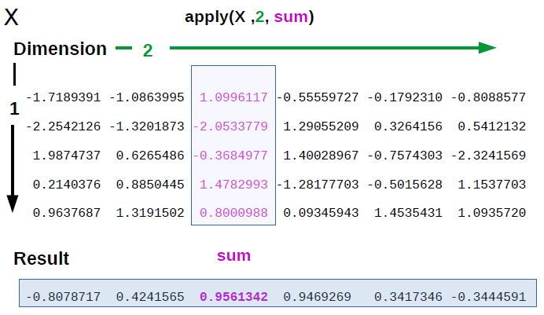

**Using lapply in R:** lapply is a given function to every element of a list and obtain a list as result.

```
# create a list of matrices:
A<-matrix(1:9, 3,3)
B<-matrix(4:15, 4,3)
C<-matrix(8:10, 3,2)
MyList<-list(A,B,C) # display the list

# extract the second column from the list of matrices, using the selection operator "["
lapply(MyList,"[", , 2)
```

```
# Another example: we now  extract the first row from the list of matrices, using the selection operator "["
lapply(MyList,"[", 1, )
```

**Using sapply in R:** sapply works as lapply, but it tries to simplify the output to the most elementary data structure that is possible. sapply returns a vector.

```
sapply(MyList, "[", 2, 1 )
## [1] 2 5 9
```